# prise_en_main_jupyter

[figure not shown]

Calcul scientifique (INF2B2)  
Prise en main Jupyter Notebook  
Exercices de prise en main

**Youssef CHAHIR**

[figure not shown]

- Ces ressources sont disponibles en ligne sur [ecampus](https://ecampus.unicaen.fr)

Cet tutoriel a pour objectif de vous faire rapidement explorer les **fonctionnalités de base** de l'interpréteur interactif **jupyter** en mode **Notebook**.

Mais tout d'abord **félicitations** d'être déjà parvenu à ouvrir ce notebook !

# Jupyter Notebook

## Installer Jupyter

En suivant le tutoriel en ligne depuis [`jupyter.org/install.html`](https://jupyter.org/install.html), il est facile d’installer tout l’écosystème Jupyter sur tout ordinateur avec `Python` et un gestionnaire de paquets (`pip` ou `conda`) installé.

Sur Windows ou Mac OS X, ou même la plupart des systèmes GNU/Linux, un installeur gratuit appelé Anaconda ([`www.anaconda.com/distribution`/](https://www.anaconda.com/distribution/)) installe tout ça en un clic !

[figure not shown]

## Lancer Jupyter

- Sous Mac ou GNU/Linux, dans un terminal : `$ jupyter-notebook`,
- Sous Windows, avec Anaconda, il y a un lanceur graphique installé.

[figure not shown]

Notebook Jupyter :

- Un fichier, à l'extension `.ipynb` (*ipy*thon *n*ote*b*ook), qui est un format de texte brut de type [JSON](https://www.json.org/).
- Un outil facile à utiliser pour les débutants et puissant pour les utilisateurs experts.
- Un outil unique pour rédiger des petits morceaux de code (exercices, TP, tutoriel, analyse de données etc), avec du texte ou une documentation, les résultats de l'exécution du code, des figures etc,
- Un fichier .ipynb (slideshow) sui peut être converti en présentation en page web statique (HTML), en document pdf (PDF) ou en script (Python ou autre)
- Permet une bonne compatibilité avec les gestionnaires de version tels que `git`.

On peut utiliser **Jupyter Lab**, la nouvelle version de l'interface utilisateur de Jupyter (plus moderne).

[jupyterlab](https://www.stat4decision.com/fr/jupyterlab-python/)

## Cellules

*Jupyter* est nommé d'après Jupiter, et pour *Ju*lia, *pyt*hon, et *R*, les trois premiers langages pour lesquels Jupyter était disponible.

→ Initialement, il a commencé sous le nom [ipython](http://www.ipython.org/) car il a été conçu pour être utilisé pour le langage de programmation Python.

- Jupyter est un environnement de développement intégré (IDE) "WYSIWYG" (What-you-see-is-what-you-get).
- Il est utilisé pour différents langages de programmation (que l'on utilise depuis un navigateur Internet) tels que des langages dynamiques interprétés comme Python mais aussi pour des langages compilés, tels que C/C++.
- Tous les logiciels de l'environnement Jupyter, sont gratuits et sous licence libre, comme Python.

Un notebook jupyter consiste en **cellules** individuelles pouvant contenir du **code** Python, du **texte** (avec formatage Markdown, HTML et LaTeX) ou des **graphiques**.

### Cellules de code

Commençons par les cellules de type Code. (c'est-à-dire préfixée par **In[ ]:**)

On est par défaut en mode **édition de code** Python !

**1)** Placez le curseur dans la 1ère cellule **In[ ]:** ci-dessous puis frappez `<enter>`.

Pour **exécuter le code** Python d'une cellule, il faut en effet frapper `<maj-enter>` (ou cliquer sur le bouton , ou encore utiliser le menu `Cell>Run and Select Below...`). Essayez !

Une ligne **Out[ ]:** devrait être apparue en dessous de la 1ère expression, affichant le résultat de celle-ci ! Le curseur est alors automatiquement passé dans la cellule d'en-dessous que vous pouvez exécuter à son tour.

*Notez qu'il est aussi possible de frapper `<ctrl-enter>` (identique à `Cell>Run`). Dans ce cas, le curseur **reste dans la cellule** après l'exécution du code.*

**2)** Pour détruire une cellule, sélectionnez-la puis cliquez sur le bouton (ou faites `Edit>Delete Cell`). Exercez-vous en détruisant la cellule ci-dessous. Puis rétablissez-la avec `Edit>Undo Delete Cell`

**3)** On peut **spliter** une cellule : pour cela *double-cliquez* d'abord dans la cellule pour l'éditer, puis placez le curseur entre les 2 lignes, et faites finalement `Edit>Split Cell`

**4)** On peut **fusionnement** plusiuers3cellules de texte avec `Edit>Merge Cell Above` ou `Edit>Merge Cell Below`

### Cellules de texte

Il existe 2 types de cellules de texte, selon le choix effectué à l'aide du menu déroulant de droite ou avec `Cell>Cell Type>...` :

- **Raw NBConvert** (texte) : cellules de texte sans aucun formatage, directement éditables sans devoir *double-cliquer* dedans ;
- **Markdown** : cellules dans lesquelles le texte est soumis à un formatage selon la syntaxe Markdown ; les éventuelles balises HTML et le code LaTeX sont également interprétés...

**5)** *S'agissant des cellules de texte au format **[Markdown](http://commonmark.org/)**, cela suppose quelques notions relatives au langage de balisage Markdown : .*

Et il est même possible d'introduire du **code LaTeX** $\LaTeX^2$ (placé entre deux caractères `$`) dans une cellule de type Markdown :

$$f(x) = \frac{1}{2}x^2 - x^{\pi \over 4}$$

L'interface graphique des notebooks Jupyte permet d'éditer des cellules de texte ou de code, et exécuter des cellules.

Pour plus d'informations :

- [Rédigez en Markdown !](https://openclassrooms.com/courses/redigez-en-markdown)
- [un Notebook assez complet sur les cellules au format Markdown](http://nbviewer.jupyter.org/github/twistedhardware/mltutorial/blob/master/notebooks/jupyter/2.%20Markdown%20%26%20LaTeX.ipynb)

Un document contient des cellules de texte (en Markdown ↑), et de code ↓.  
*Ceci est une cellule de texte*.

```python
3+2
```

```
5
```

## Sauvegarder et imprimer un notebook

- Pour **sauvegarder** un notebook, on peut utiliser e bouton (ou le menu `File>Save and Checkpoint`). Sachez que jupyter effectue par défaut des sauvegardes à intervalle régulier, et que `File>Revert to Checkpoint` permet de revenir à un état enregistré.
- Pour **imprimer un notebook**, n'utilisez pas la commande d'impression de votre navigateur web depuis la fenêtre de notebook, le résultat sera très mauvais. La bonne méthode consiste à faire au préalable depuis le menu `File>Print Preview`. Mais il est peut être préférable de télécharger une version numérique du notebook sur l'ordinateur local dans le format qui vous convient comme le HTML pour obtenir une page web statique avec le menu `File>Download as`... ou pdf ...

## Créer et exécuter des fichiers Python depuis jupyter

Documentation sur les différentes commandes : https://ipython.readthedocs.io/en/stable/interactive/magics.html`

### Créer un script :

```python
%%writefile hello.py
print("Bonjour de Python!")
```

```
Overwriting hello.py
```

### Exécution d’une commande :

Pour exécuter une commande shell, on utilise un point d’exclamation (!) qui doit toujours précéder la commande en question.

Par exemple la commande «ls» (ou dir sur windows) permet de montrer tous les éléments qui se trouvent au niveau du répertoire actuel ainsi que son emplacement.

Si le résultat tarde à s’afficher, on peut relancer le kernel ou le noyau « IPython »

Dans Python avec Jupyter, on a accès au shell/terminal

```python
%ls -l
```

```
total 1912
drwxr-xr-x@ 10 chahir  staff     320  2 jan 13:30 figs/
-rw-r--r--   1 chahir  staff      28  2 jan 19:59 hello.py
-rw-r--r--@  1 chahir  staff  445427  2 jan 19:10 prise_en_main_jupyter.html
-rwxr-xr-x@  1 chahir  staff  353836  2 jan 19:59 prise_en_main_jupyter.ipynb*
-rw-r--r--   1 chahir  staff  168292  2 jan 19:36 res.pdf
```

```python
!ls -l
```

```
total 1912
drwxr-xr-x@ 10 chahir  staff     320  2 jan 13:30 figs
-rw-r--r--   1 chahir  staff      28  2 jan 19:59 hello.py
-rw-r--r--@  1 chahir  staff  445427  2 jan 19:10 prise_en_main_jupyter.html
-rwxr-xr-x@  1 chahir  staff  353836  2 jan 19:59 prise_en_main_jupyter.ipynb
-rw-r--r--   1 chahir  staff  168292  2 jan 19:36 res.pdf
```

```python
!python3 hello.py
```

```
Bonjour de Python!
```

```python
!python3 --version
```

```
Python 3.7.9
```

```python
# (ici dans le terminal, depuis Python dans Jupyter ou IPython, avec !commande ...)
!file "prise_en_main_jupyter.ipynb"
```

```
prise_en_main_jupyter.ipynb: HTML document text, UTF-8 Unicode text, with very long lines
```

```python
import os
statinfo = os.stat('prise_en_main_jupyter.ipynb')
statinfo
```

```
os.stat_result(st_mode=33261, st_ino=8621370351, st_dev=16777220, st_nlink=1, st_uid=502, st_gid=20, st_size=353836, st_atime=1609614006, st_mtime=1609613972, st_ctime=1609613972)
```

```python
!head "prise_en_main_jupyter.ipynb"
```

```
{
 "cells": [
  {
   "cell_type": "markdown",
   "metadata": {
    "slideshow": {
     "slide_type": "slide"
    }
   },
   "source": [
```

```python
!grep "Jupyter" prise_en_main_jupyter.ipynb  | head -n1
```

```
    "    <FONT size=\"6\">  Prise en main Jupyter Notebook </FONT><br>\n",
```

## Des exemples en Python

### Ecrire des programmes et les exécuter depuis Jupyter

> 1. Des petits exemples d'utilisation de Python
> 2. Utilisation de modules Python

```python
def somme (x,y):
    return (x+y)
```

```python
x = somme(3,4)
x
```

```
7
```

```python
nombres = [2, 4, 6, 8]
produit = 1
for nombre in nombres:
    produit *= nombre

print("Le produit de ces", len(nombres), "nombres est", produit)
```

```
Le produit de ces 4 nombres est 384
```

```python
import datetime

print("Date actuelle :")
print(datetime.datetime.now())
```

```
Date actuelle :
2021-01-02 20:00:22.735349
```

```python
def fib(n):
    """ Affiche les premières valeurs de la suite de Fibonacci <= n."""
    a, b = 0, 1
    while a < n:
        print(a, end=' ')
        a, b = b, a+b
    print()

fib(1000)
```

```
0 1 1 2 3 5 8 13 21 34 55 89 144 233 377 610 987
```

### Récupération des entrées / sorties précédentes

```python
3 * 3
```

```
9
```

```python
#Entrée précédente (60)

In[60]
```

```
'3 * 3'
```

```python
#Sortie 62

Out[62]
```

```
'3 * 3'
```

```python
# Toutes les entrées
In
```

[output not shown]

[output cut: 10 more lines]

```
 "get_ipython().system('python3 --version')",
 '# (ici dans le terminal, depuis Python dans Jupyter ou IPython, avec !commande ...)\nget_ipython().system(\'file "prise_en_main_jupyter.ipynb"\')',
 "import os\nstatinfo = os.stat('prise_en_main_jupyter.ipynb')\nstatinfo",
 'get_ipython().system(\'head "prise_en_main_jupyter.ipynb"\')',
 'get_ipython().system(\'grep "Jupyter" prise_en_main_jupyter.ipynb  | head -n1\')',
 'def somme (x,y):\n    return (x+y)',
 'x = somme(3,4)\nx',
 'nombres = [2, 4, 6, 8]\nproduit = 1\nfor nombre in nombres:\n    produit *= nombre\n\nprint("Le produit de ces", len(nombres), "nombres est", produit)',
 'import datetime\n\nprint("Date actuelle :")\nprint(datetime.datetime.now())',
 'def fib(n):\n    """ Affiche les premières valeurs de la suite de Fibonacci <= n."""\n    a, b = 0, 1\n    while a < n:\n        print(a, end=\' \')\n        a, b = b, a+b\n    print()\n\nfib(1000)',
 '3 * 3',
 '#Entrée précédente (26)\n\nIn[26]',
 '#Entrée précédente (60)\n\nIn[60]',
 '#Sortie 62\n\nOut[62]',
 '# Toutes les entrées\nIn']
```

```python
# Toutes les sorties
Out
```

[output not shown]

[output cut: 97 more lines]

```
  '# (ici dans le terminal, depuis Python dans Jupyter ou IPython, avec !commande ...)\nget_ipython().system(\'file "prise_en_main_jupyter.ipynb"\')',
  "import os\nstatinfo = os.stat('prise_en_main_jupyter.ipynb')\nstatinfo",
  'get_ipython().system(\'head "prise_en_main_jupyter.ipynb"\')',
  'get_ipython().system(\'grep "Jupyter" prise_en_main_jupyter.ipynb  | head -n1\')',
  'def somme (x,y):\n    return (x+y)',
  'x = somme(3,4)\nx',
  'nombres = [2, 4, 6, 8]\nproduit = 1\nfor nombre in nombres:\n    produit *= nombre\n\nprint("Le produit de ces", len(nombres), "nombres est", produit)',
  'import datetime\n\nprint("Date actuelle :")\nprint(datetime.datetime.now())',
  'def fib(n):\n    """ Affiche les premières valeurs de la suite de Fibonacci <= n."""\n    a, b = 0, 1\n    while a < n:\n        print(a, end=\' \')\n        a, b = b, a+b\n    print()\n\nfib(1000)',
  '3 * 3',
  '#Entrée précédente (26)\n\nIn[26]',
  '#Entrée précédente (60)\n\nIn[60]',
  '#Sortie 62\n\nOut[62]',
  '# Toutes les entrées\nIn',
  '# Toutes les sorties\nOut']}
```

```python
1+2
```

```
3
```

```python
1+2;
```

```python
x = 2; x
```

```
2
```

### Système d'exploitation

```python
import platform

plt = platform.system()
print(platform.system())
print(platform.release())
print(platform.version())

if plt == "Windows":
    print("Votre système est Windows")
    # do x y z
elif plt == "Linux":
    print("Votre système est Linux")
    # do x y z
elif plt == "Darwin":
    print("Votre système est MacOS")
    # do x y z
else:
    print("Sysème non identifié")
```

```
Darwin
17.7.0
Darwin Kernel Version 17.7.0: Mon Aug 31 22:11:23 PDT 2020; root:xnu-4570.71.82.6~1/RELEASE_X86_64
Votre système est MacOS
```

```python
import math
#Aide sur cos ?
math.cos?
```

### Mesure du temps et profilage de programmes

```python
%timeit fib(10)
```

[output not shown]

[output cut: 8097 more lines]

```python
def fib(N):
    """
    Retourne la liste des N premiers nombres de la suite de Fibonacci.
    """
    f0, f1 = 0, 1
    f = [1] * N
    for n in range(1, N):
        f[n] = f0 + f1
        f0, f1 = f1, f[n]

    return f

print(fib(10))
```

```
[1, 1, 2, 3, 5, 8, 13, 21, 34, 55]
```

Profilage des programmes (combien de temps CPU passé sur quelles fonctions)

```python
result = %time fib(50)
```

```
CPU times: user 11 µs, sys: 0 ns, total: 11 µs
Wall time: 14.1 µs
```

## Graphiques dans un notebook

*Si vous exécutez la fonction magique `%pylab inline`, les packages **Numpy** et **Matplotlib** sont importés et il sera possible de dessiner des graphiques de façon "inline" (intégrés au notebook).*

```python
%pylab inline
```

*L'exemple de code suivant sera alors exécutable.*

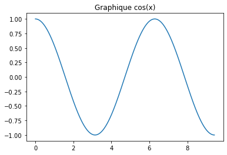

```python
# Fait appel à numpy (linspace et pi)
x = linspace(0, 3*pi, 500)

# Fait appel à matplotlib (plot et title)
plot(x, cos(x))
title('Graphique cos(x)')
```

### Intégrer une image :

```python
from IPython.display import Image
Image("figs/UNICAEN-logo-NOIR-horizontal.png", width = 100, height = 100)
```

[output not shown]

### Intégrer une vidéo youtube :

```python
from IPython.display import YouTubeVideo
YouTubeVideo('Rc4JQWowG5I')
```

[video not shown]

### Intégrer une page web :

```python
from IPython.display import HTML
HTML('<IFrame src="https://fr.wikipedia.org/wiki/Jupyter" width=700 height=350>')
```

[interactive chart not shown]